# ButterflyMultivariate

Tyson Wepprich

Friday, March 27, 2015

I’m new to ordination, so I tried a few things that made sense to me with a little bit of reading. Brief summary: -Lots of variation in landuse and pesticide use between sites, not a lot between years. -It might be good to focus on sites with high agricultural use to focus in on pesticide effects. -I haven’t tested effects of using different scales (200m to 10km buffers around sites) of aggreagting land use and pesticides. -Butterfly abundance being used right now, but we could also try presence/absence, or focus on butterfly species we anticipate would be heavily affected by farmland management. Also, there may be better ways to scale the abundance, because much of the site differences could be due to, well, site differences (in transect length, habitat, observer, etc.).

```r
library(plyr)
library(dplyr)
library(reshape)
library(vegan)
```

```r
library(ggplot2)


pest <- read.csv("../Pesticides/pest_bflybuff_overtime.csv", header = TRUE)
names(pest) <- c("Year", "SiteID", "buffer", "compound", "high_kg_buff", "low_kg_buff", "ag_pix_buff")
pest$SiteID <- as.character(pest$SiteID)

#extract landcover change trends for model, won't have yearly variation like pesticides or weather
#also might be good to classify sites with PCA for landcover context using landclass percentages
lc <- read.csv("../Landcover/LC_bflybuff_overtime.csv", header = TRUE)
names(lc) <- c("SiteID", "reclass", "buffer", "Year", "total_pix", "km2")
lc$reclass <- mapvalues(lc$reclass, from = c(1:7), to = c("water", "urban", "barren", "forest", "grass", "farm", "wetland"))
lc$SiteID <- as.character(lc$SiteID)

BflyPops <- readRDS("BflyPops.rds")

#choose buffer
#I haven't played around with this at all to see if some scales show different results

#bring together landcover and pesticide info
buffer <- 5000 #200, 400, 1000, 2000, 5000, 10000 meter radii around sites
lc_subsample <- lc[lc$buffer == buffer, ]
pest_subsample <- pest[pest$buffer == buffer, ]
env <- merge(lc_subsample, pest_subsample, by = c("Year", "SiteID"))

site_lc <- data.frame(cast(lc_subsample, SiteID + Year ~ reclass, value = "km2"))
site_lc[is.na(site_lc)] <- 0

site_pest <- data.frame(cast(pest_subsample, SiteID + Year ~ compound, value = "high_kg_buff"))
site_pest[is.na(site_pest)] <- 0

env <- merge(site_lc, site_pest, by = c("SiteID", "Year"), all.x = TRUE, all.y = FALSE)

#make matrix of species abundances for ordination
spec_site_mat <- data.frame(cast(BflyPops, SiteID + Year ~ Species, value = "TrpzInd"))
spec_site_mat[is.na(spec_site_mat)] <- 0

env <- merge(spec_site_mat[, c(1:2)], env, by = c("SiteID", "Year"))
#NA's when buffers have no farmland => no estimated pesticide use
env[is.na(env)] <- 0

#each row is a site x year observation in species matrix (with columns for site and year factors)
spec_site <- merge(env[, c(1:2)], spec_site_mat, by = c("SiteID", "Year"))


#Scaling
#I'm new to this, so alternative suggestions welcome
#scale land use so total in each buffer (row) sum to 1
#scale pesticides by column, standardize
env[, 3:9] <- decostand(env[, 3:9], 'total')
env[, 10:17] <- decostand(env[, 10:17], 'standardize')
env$SiteID <- as.factor(env$SiteID)
env$Year <- as.factor(env$Year)

#tried a couple different scalings for butterfly abundance
#it might make sense to square root them first between they have huge variation
spec_site_hell <- decostand(spec_site[, -c(1:2)], 'hell')
spec_site_wisc <- wisconsin(spec_site[, -c(1:2)])

#trying out different unconstrained and constrained rdas
test <- rda(spec_site_hell)
test <- rda(spec_site_hell ~ ., env[,c(3:9)])
test <- rda(spec_site_hell ~ env[,2])

#try out site and year as factors in species ordination
#repeated below using adonis function instead
test <- rda(spec_site_hell ~ factor(env$SiteID) + factor(env$Year))

(r2 <- RsquareAdj(test)$r.squared)
```

```
## [1] 0.8043
```

```r
(r2adj <- RsquareAdj(test)$adj.r.squared)
```

```
## [1] 0.7643
```

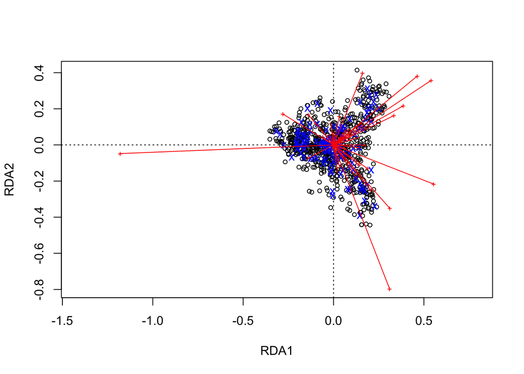

```r
#Make some ordination plots of spatial and temporal variation in environmental variables.
plot(test, scaling = 2)
spe.sc <- scores(test, choices = 1:2, display = "sp")
arrows(0,0, spe.sc[,1], spe.sc[,2], length = 0, lty = 1, col = "red")
```

```r
#PERMANOVA shows that much more butterfly variation over sites than between years (when looking at entire state)
#This may not actually say much about yearly variation at a particular site, though.
ado <- adonis(spec_site[3:42] ~ as.factor(SiteID) + as.factor(Year), data = spec_site, permutations = 999,
              method = "bray")
ado
```

```
##
## Call:
## adonis(formula = spec_site[3:42] ~ as.factor(SiteID) + as.factor(Year),      data = spec_site, permutations = 999, method = "bray")
##
## Terms added sequentially (first to last)
##
##                    Df SumsOfSqs MeanSqs F.Model    R2 Pr(>F)
## as.factor(SiteID) 104     105.0   1.010    19.1 0.709  0.001 ***
## as.factor(Year)    15      12.4   0.825    15.6 0.084  0.001 ***
## Residuals         581      30.7   0.053         0.207
## Total             700     148.1                 1.000
## ---
## Signif. codes:  0 '***' 0.001 '**' 0.01 '*' 0.05 '.' 0.1 ' ' 1
```

```r
## TYSON - variables are considered sequentially - so if you want partial results, you have to rerun in reverse order (if you only have 2).
## therefore:

ado2 <- adonis(spec_site[3:42] ~ as.factor(Year) + as.factor(SiteID) , data = spec_site, permutations = 999,
              method = "bray")
ado2 ## see the difference?
```

```
##
## Call:
## adonis(formula = spec_site[3:42] ~ as.factor(Year) + as.factor(SiteID),      data = spec_site, permutations = 999, method = "bray")
##
## Terms added sequentially (first to last)
##
##                    Df SumsOfSqs MeanSqs F.Model    R2 Pr(>F)
## as.factor(Year)    15      16.6   1.109    21.0 0.112  0.001 ***
## as.factor(SiteID) 104     100.8   0.969    18.3 0.680  0.001 ***
## Residuals         581      30.7   0.053         0.207
## Total             700     148.1                 1.000
## ---
## Signif. codes:  0 '***' 0.001 '**' 0.01 '*' 0.05 '.' 0.1 ' ' 1
```

```r
ado3 <- adonis(spec_site[3:42] ~ as.factor(Year) * as.factor(SiteID) , data = spec_site, permutations = 999,
              method = "bray")
ado3  ## oops I broke the model :D
```

```
##
## Call:
## adonis(formula = spec_site[3:42] ~ as.factor(Year) * as.factor(SiteID),      data = spec_site, permutations = 999, method = "bray")
##
## Terms added sequentially (first to last)
##
##                                    Df SumsOfSqs MeanSqs F.Model    R2
## as.factor(Year)                    15      16.6       1       0 0.112
## as.factor(SiteID)                 104     100.8       1       0 0.680
## as.factor(Year):as.factor(SiteID) 581      30.7       0       0 0.207
## Residuals                           0       0.0    -Inf         0.000
## Total                             700     148.1                 1.000
##                                   Pr(>F)
## as.factor(Year)                        1
## as.factor(SiteID)                      1
## as.factor(Year):as.factor(SiteID)      1
## Residuals
## Total
```

```r
#I think I'm using the strata correctly for the permutation tests, but might be wrong

## TYSON - these are right, depending on the question :o)
# Adonis really asks whether the levels of a group (or groups) differ significantly in ordination space (all the dimensions, unlike envfit).
# the first asks whether the years differ significantly when you account for repeated sampling, the second whether sites differ significantly when you account for repeated sampling

## I think it would be more interesting to say, do non-organics vs organics have different compositions, or etc etc etc. But I think I'm jumping the gun with that one. - Liv

ado <- adonis(spec_site[3:42] ~ as.factor(Year), data = spec_site, strata = spec_site$SiteID, permutations = 999,
              method = "bray")
ado <- adonis(spec_site[3:42] ~ as.factor(SiteID), data = spec_site, strata = spec_site$Year, permutations = 999,
              method = "bray")


#How much does pesticide use vary over time and space?
#A lot over different sites, not a lot of variation between years
#Idea: Only analyze sites that actually have agriculure/pesticides nearby. Could be that the big variation
#is between forested/natural and ag/urban sites in both abundance/species composition

## TYSON - question: does a change in the *composition* of pesticide usage constitute an ecolgoically relevant change? I'm just playing devils advocate here because if we *shift* from one type to another which has equivalent effects, they're functionally equivalent but may lead to a statisically significant cahnge..

ado_yr <- adonis(env[, 10:17] ~ as.factor(Year), data = env, strata = env$SiteID, permutations = 999,
              method = "euclidean")
ado_yr
```

```
##
## Call:
## adonis(formula = env[, 10:17] ~ as.factor(Year), data = env,      permutations = 999, method = "euclidean", strata = env$SiteID)
##
## Terms added sequentially (first to last)
##
##                  Df SumsOfSqs MeanSqs F.Model    R2 Pr(>F)
## as.factor(Year)  15       889    59.3    8.62 0.159  0.001 ***
## Residuals       685      4711     6.9         0.841
## Total           700      5600                 1.000
## ---
## Signif. codes:  0 '***' 0.001 '**' 0.01 '*' 0.05 '.' 0.1 ' ' 1
```

```r
ado_site <- adonis(env[,10:17] ~ as.factor(SiteID), data = env, strata = env$Year, permutations = 999,
              method = "euclidean")

ado_site
```

```
##
## Call:
## adonis(formula = env[, 10:17] ~ as.factor(SiteID), data = env,      permutations = 999, method = "euclidean", strata = env$Year)
##
## Terms added sequentially (first to last)
##
##                    Df SumsOfSqs MeanSqs F.Model    R2 Pr(>F)
## as.factor(SiteID) 104      3233   31.09    7.83 0.577  0.001 ***
## Residuals         596      2367    3.97         0.423
## Total             700      5600                 1.000
## ---
## Signif. codes:  0 '***' 0.001 '**' 0.01 '*' 0.05 '.' 0.1 ' ' 1
```

[figure not shown]

```r
#Trying to figure out a way to plot means/SEs of groups (like sites or years)
#These mostly are crappy and me just playing around
#Good way to plot ordinations that you know of, Liv?

### TYSON: ha, I love plotting them. It's an ordiellipse. The thing is, adonis() is sensitive to dispersion, so you need to run a betadisper() as well. I've got example code in the multivariate BBS stuff I pushed.

# e.g. NMDS styles

nmds_env <- metaMDS(env[,10:17]) # problems
### TYSON - problem - these are scaled or something right? that is suboptimal for the multivariate. (we should talk more about this on the skype)

# for ggplot ordiellipses: https://oliviarata.wordpress.com/2014/04/17/ordinations-in-ggplot2/
# an RDA version Monica requested: https://oliviarata.wordpress.com/2014/09/06/rda-in-ggplot2/



dis <- vegdist(spec_site[3:42])
#landcover dissimilarity
dis <- vegdist(env[, 3:9], method = "euclidean")

years <- as.factor(spec_site$Year)
sites <- as.factor(spec_site$SiteID)

mod <- betadisper(dis, sites, type = "centroid")
try(plot(mod)) # these keep breaking my computer
try(ordiellipse(mod, sites))
```

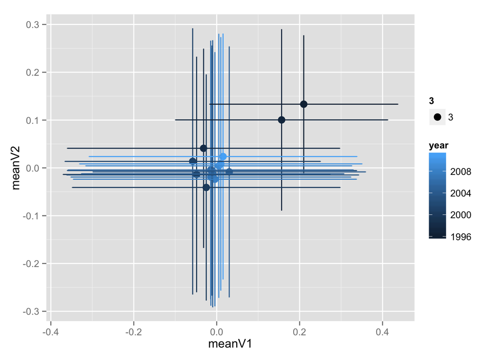

```r
pcoa<- cmdscale(dis)
# plot them with different symbols for groups
pcoa <- as.data.frame(pcoa)
pcoa$year <- spec_site$Year
pcoa$site <- spec_site$SiteID

yrs <- pcoa %>%
  group_by(year) %>%
  summarise(meanV1 = mean(V1), meanV2 = mean(V2), sdV1 = sd(V1), sdV2 = sd(V2))

p <- ggplot(yrs, aes(x = meanV1, y = meanV2, colour = year))
p + geom_point(aes(size = 3)) + geom_errorbar(aes(ymax = meanV2 + sdV2, ymin = meanV2 - sdV2)) +
  geom_errorbarh(aes(xmax = meanV1 + sdV1, xmin = meanV1 - sdV1))
```

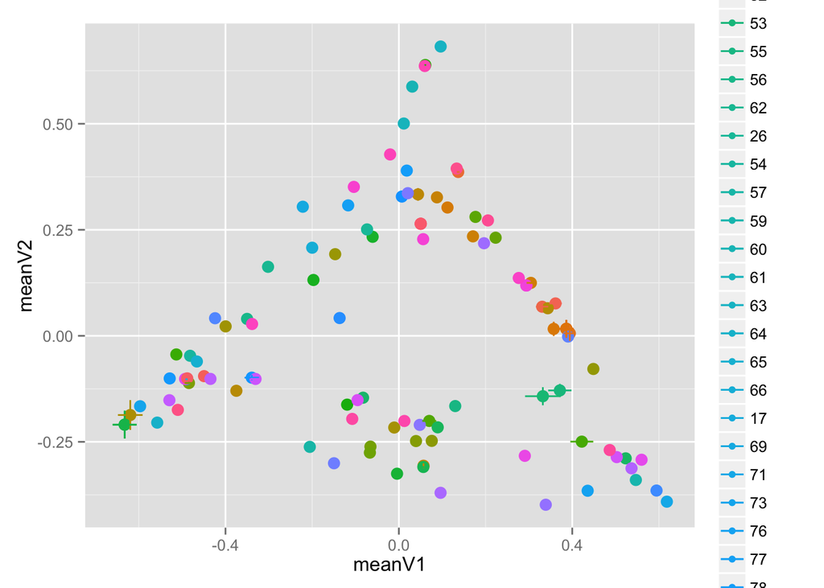

```r
sites <- pcoa %>%
  group_by(site) %>%
  summarise(meanV1 = mean(V1), meanV2 = mean(V2), sdV1 = sd(V1), sdV2 = sd(V2))
q <- ggplot(sites, aes(x = meanV1, y = meanV2, colour = site))
q + geom_point(aes(size = 3)) + geom_errorbar(aes(ymax = meanV2 + sdV2, ymin = meanV2 - sdV2)) +
  geom_errorbarh(aes(xmax = meanV1 + sdV1, xmin = meanV1 - sdV1))
```

```r
# partial mantel test of pesticide effects while controlling for land use
# another approach for analyzing multivariate differences between sites
# not a lot jumping out that's interesting though
pest.pc <- prcomp(env[10:17], scale = FALSE)
pc <- scores(pest.pc, display = "sites", choices = 1:4)
  pest.dis <- vegdist(pc, method = "euclid")

lc.pc <- prcomp(env[3:9], scale = TRUE)
pc <- scores(lc.pc, display = "sites", choices = 1:4)
lc.dis <- vegdist(pc, method = "euclid")

  bflydis <- vegdist(spec_site_hell)
  man <- mantel.partial(bflydis, pest.dis, lc.dis)
```

## Some more text-y suggestions:

(the rest are in the code above, some of which are indicated by `TYSON`. Fancy, I know.)

Biggest problem I think we’ll have is combining strata. There is only 1 slot. Makes repeated measures hard.

1. Within the most proximate buffer to sites, has community composition changed over time?
   1. Adonis ~ time, strata = site
   2. I think it would also be nice to separate ordinations and plot the *shift* in the each site through time - seeing where sites shift to and why? If we are correct that neonics are making sites less speciose/pollution tolerant taxa, then we should see sites (particulary those with consistently high rates of pesticide application) shift.
2. If so, have communities shifted to more ‘typical’ impacted communities?
1. Betadisper - niche space compression?
2. Actual ID of species (or Mclust of species).

*For more discussion!!* FYI I haven’t done that stuff below. Just a few things.

```r
# Q1

# this is the species matrix I'm going to use: spec_site[, -c(1:2)]
head(spec_site, 2)
```

```
##   SiteID Year American.Copper American.Lady Azures Black.Swallowtail
## 1      1 1996               0             0  528.7             30.50
## 2      1 1997               0            15  146.7             80.03
##   Cabbage.White Clouded.Sulphur Common.Buckeye Common.Wood.Nymph
## 1          1511           117.2              0             659.4
## 2          1928           176.8              0             770.0
##   Eastern.Comma Eastern.Tailed.Blue Eastern.Tiger.Swallowtail
## 1          59.5               90.58                     58.90
## 2          63.5               83.58                     63.76
##   European.Skipper Fiery.Skipper Gray.Hairstreak Great.Spangled.Fritillary
## 1            680.0             0               0                     167.2
## 2            366.5             0               0                     140.7
##   Hackberry.Emperor Hobomok.Skipper Horace.s.Duskywing Juvenal.s.Duskywing
## 1                 0           34.32                  0                   0
## 2                 0           17.91                  0                  21
##   Least.Skipper Little.Glassy.Wing Little.Wood.Satyr Meadow.Fritillary
## 1         130.9              15.05             75.06                 0
## 2         185.3               9.00             90.52                 0
##   Monarch Mourning.Cloak Northern.Broken.Dash Northern.Pearly.Eye
## 1   533.8           29.0                   27                  18
## 2   926.2           50.5                    0                  32
##   Orange.Sulphur Painted.Lady Pearl.Crescent Peck.s.Skipper Question.Mark
## 1           1281            0           1995          37.71            19
## 2           1376            0           1381          27.03            60
##   Red.Admiral Red.spotted.Purple Silver.spotted.Skipper
## 1         0.0              60.09                  60.70
## 2       100.3             116.43                  58.57
##   Spicebush.Swallowtail Tawny.edged.Skipper Viceroy Wild.Indigo.Duskywing
## 1                    21                   0   237.8                     0
## 2                    16                   0   205.4                     0
##   Zabulon.Skipper
## 1            26.5
## 2            20.0
```

```r
nmds_blfy <- metaMDS(spec_site[, -c(1:2)])
```

```
## Square root transformation
## Wisconsin double standardization
```

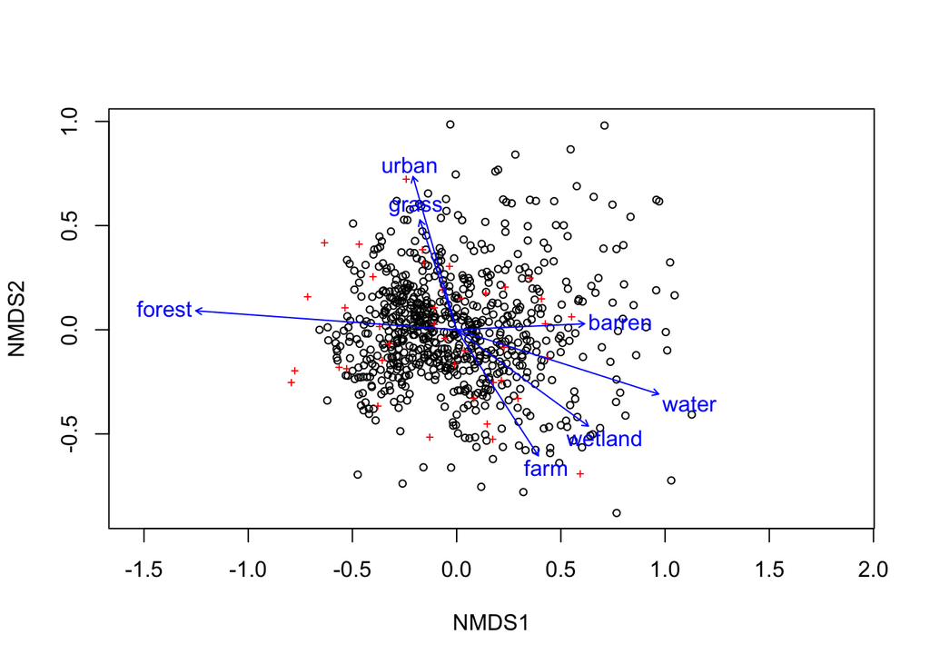

```r
plot(nmds_blfy)

env_blfy <- envfit(nmds_blfy ~ barren + farm + forest + grass + urban + water + wetland, env[, c(1, 3:9)],
                   strata = "SiteID")

plot(env_blfy, add = T)
```

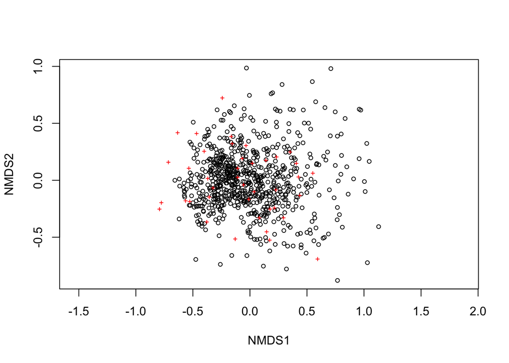

```r
plot(nmds_blfy)
```

```r
surfing_bfly <- with(env, ordisurf(nmds_blfy, farm, col = "cornflowerblue"))
```

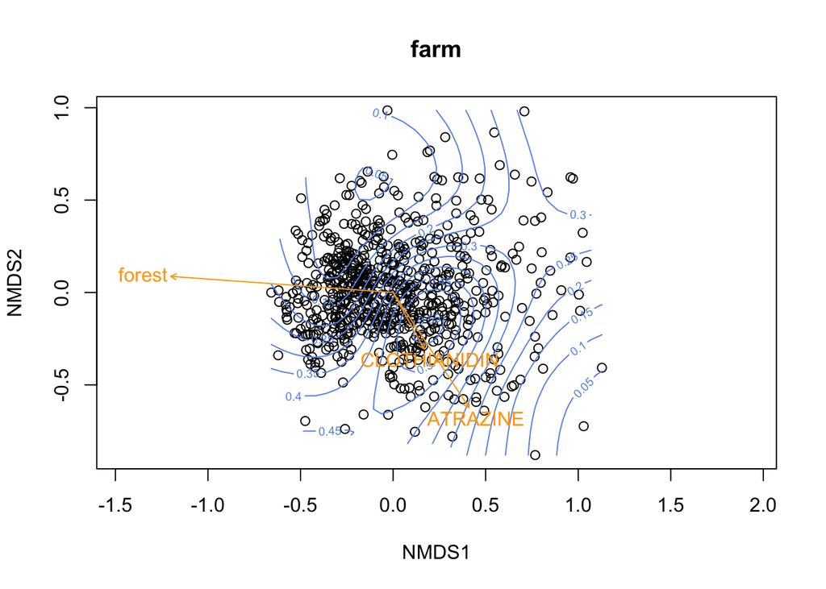

```r
env_bfly2 <- with(env, envfit(nmds_blfy ~ ATRAZINE * CLOTHIANIDIN * forest,
                 data = env,
                 strata = Year))
plot(env_bfly2, add = T, col = "orange")
```